# Part I - Loan Dataset Exploration From Prosper

## by Veronica Isiaho

## 1.0 Introduction

> The dataset that will be used for this project is available via [this url](https://s3.amazonaws.com/udacity-hosted-downloads/ud651/prosperLoanData.csv). It entails loan details of customers entailing their loan status, credit grade, loan term etc.

## 1.1.0 Main Objective

> The main aim of this project is to identify what factors affect a loan’s outcome status.

### 1.1.1 Specific Objectives

> 1. To find out what affects the borrower’s APR or interest rate.
> 2. To identify if there are differences between loans depending on how large the original loan amount was.

## 2.0 Preliminary Data Wrangling

> I'll explore the data to find out if there are any quality issues which will be corrected during data cleaning stage later in this notebook. Below are the process I'll perform during this stage:
> - a. Check the size of dataframe (find out the number of rows and columns)
> - b. Check for Missing values
> - c. Check if there are any duplicates
> - d. Confirm if the variables are in the right data types

### 2.2.0 Choosing the Features for Analysis

> I'll identify the features with over 80% missing data and drop them. I'll then drop features that have no influence in determining the loan status.

|  | missing_values | percent_missing | percent_complete |
| --- | --- | --- | --- |
| GroupKey | 100596 | 88.29 | 11.71 |
| TotalProsperLoans | 91852 | 80.62 | 19.38 |
| TotalProsperPaymentsBilled | 91852 | 80.62 | 19.38 |
| OnTimeProsperPayments | 91852 | 80.62 | 19.38 |
| ProsperPaymentsLessThanOneMonthLate | 91852 | 80.62 | 19.38 |
| ProsperPaymentsOneMonthPlusLate | 91852 | 80.62 | 19.38 |
| ProsperPrincipalBorrowed | 91852 | 80.62 | 19.38 |
| ProsperPrincipalOutstanding | 91852 | 80.62 | 19.38 |
| ScorexChangeAtTimeOfListing | 95009 | 83.39 | 16.61 |
| LoanFirstDefaultedCycleNumber | 96985 | 85.12 | 14.88 |

### 2.2.1 Feature Engineering

Having 'CreditScoreRangeLower' and 'CreditScoreRangeUpper', I'll get the difference between these two features and that will be the credit score.

**Observation**

**Observation**

> Having the EmploymentStatusDuration in months, I'll change it to years by dividing by 12 and create a new column name (EmploymentDuration).

## 3.0 Univariate Exploration

> In this section, I'll investigate distributions of individual variables.

### 1. What is the value count for the unique values in Categorical Features?

> Assessing the data and understanding the number of unique values each categorical feature is great. This will help in finding out how the features are.

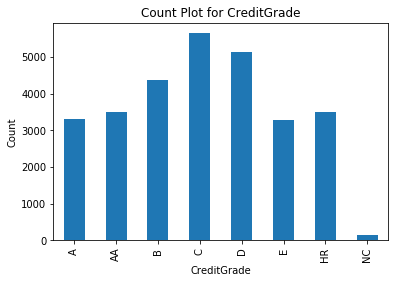

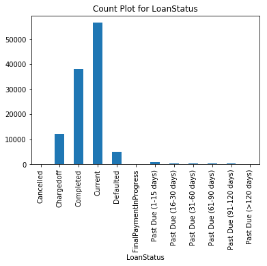

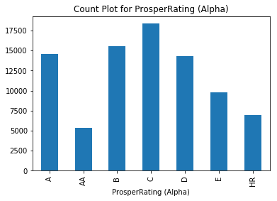

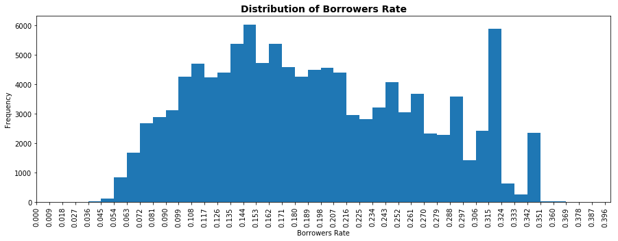

## 4.0 Bivariate Exploration

> This section willinvestigate relationships between pairs of variables in the data.

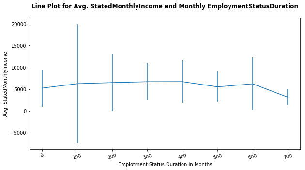

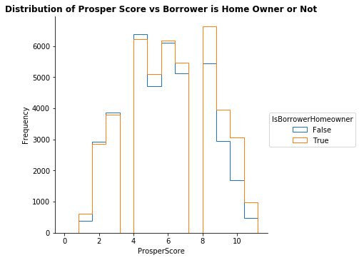

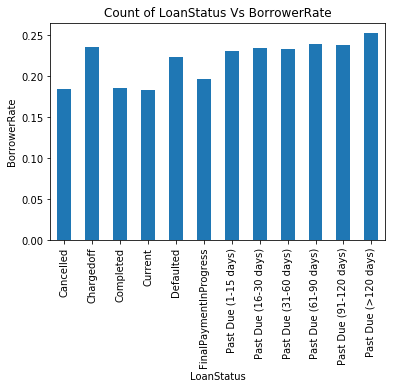

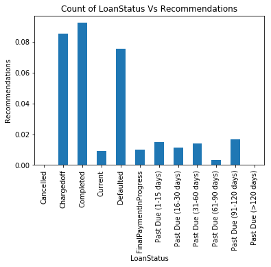

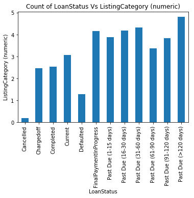

### Of the features you investigated, were there any unusual distributions? Did you perform any operations on the data to tidy, adjust, or change the form of the data? If so, why did you do this?

> I did the changes on the Trades never Delinquent so that I could be able to plot true values that show the correct data distribution for the Trades never delinquent.

### Was there any interesting relationships between the other features (not the main feature(s) of interest)?

> These other features of interest were as listed below:
> - 'BorrowersState',
> - 'IsBorrowerHomeowner',
> - 'CurrentlyInGroup',
> - 'DateCreditPulled',
> - 'CreditScoreRangeLower',
> - 'FirstRecordedCreditLine',
> - 'CurrentCreditLines',
> - 'OpenCreditLines',
> - 'TotalCreditLinespast7years',
> - 'OpenRevolvingAccounts',
> - 'OpenRevolvingMonthlyPayment',
> - 'CurrentDelinquencies',
> - 'AmountDelinquent',
> - 'DelinquenciesLast7Years',
> - 'RevolvingCreditBalance',
> - 'TotalTrades',
> - 'TradesNeverDelinquent (percentage)',
> - 'TradesOpenedLast6Months',
> - 'DebtToIncomeRatio',
> - 'IncomeRange',
> - 'StatedMonthlyIncome',
> - 'LoanCurrentDaysDelinquent',
> - 'Recommendations'

## 5.0 Multivariate Exploration

> I'll create plots of three or more variables to investigate your data even further.

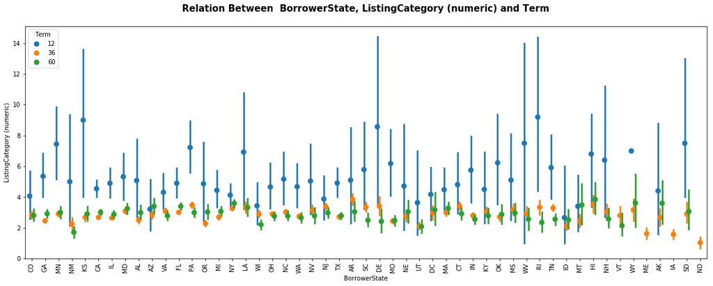

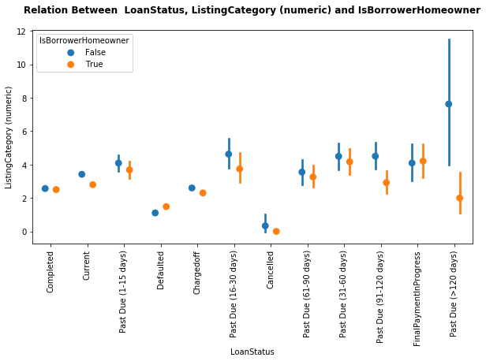

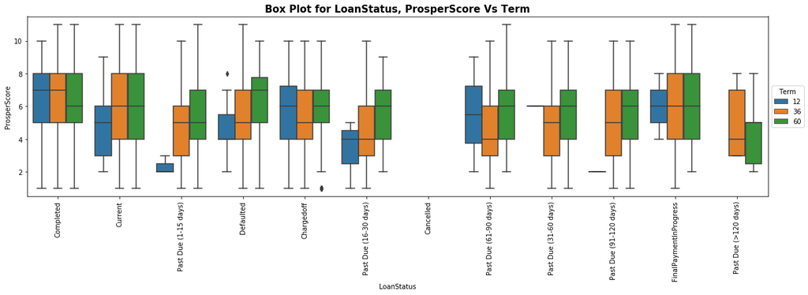

#### What's the relation between Loan Status, Prosper Score and Term

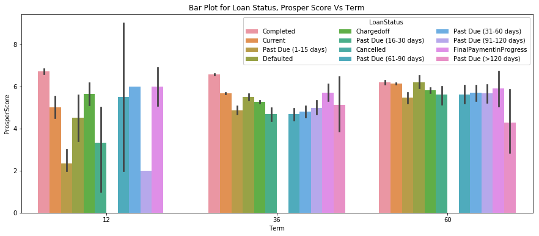

#### What's the relation between Loan Status, Prosper Score and Recommendations?

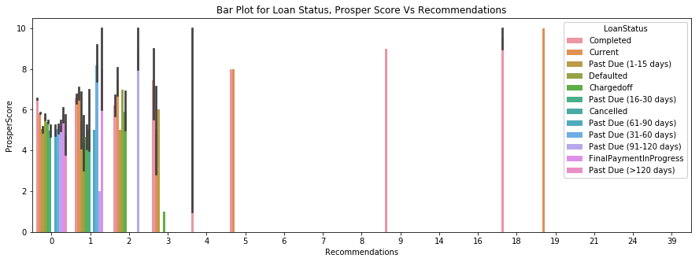

## 6.0 Exploratory Analysis

## 7.0 Conclusions

> It was noted that borrowers who had less repayment term period of 12 months were able to complete their loan payments. majority of those who had high prosper score and recommendations scores had current loans and others completed paying their loans. High income earners with income range of above 100,000 dollars secured loans with long term period.

> There was a link on the income debt ration to loan status. The borrowers with high debt to income ratio defaulted their loans and also had most of their loans in past due. I also noted that the borrowers with loans that had high borrowers rate defaulted their loans.

> When considering to give a loan, the features for consideration are:
> - a. Income to debt ratio,
> - b. Revolving Accounts
> - c. Current Revolving Accounts
> - d. Total Trades
> - e. Term Duration
> - f. Recommendation Scores
> - g. Prosper Scores
> - h. Monthly Revolving Amounts
> - i. Borrowers Rate